# SDD

Daniel Dominguez

## First step is to read in the data and make it workable, we’ll then filter the data to 1984 and beyond

```r
raw_sdd <- raw_sdd %>%
  select(
    date = ActivityStartDate,
    parameter = CharacteristicName,
    parm_cd = USGSPCode,
    units = ResultMeasure.MeasureUnitCode,
    SiteID = MonitoringLocationIdentifier,
    org = OrganizationFormalName,
    org_id = OrganizationIdentifier,
    time = ActivityStartTime.Time,
    value = ResultMeasureValue,
    sample_method = SampleCollectionMethod.MethodName,
    analytical_method = ResultAnalyticalMethod.MethodName,
    particle_size = ResultParticleSizeBasisText,
    date_time = ActivityStartDateTime,
    media = ActivityMediaName,
    type = ActivityMediaSubdivisionName,
    sample_depth = ActivityDepthHeightMeasure.MeasureValue,
    sample_depth_unit = ActivityDepthHeightMeasure.MeasureUnitCode,
    fraction = ResultSampleFractionText,
    status = ResultStatusIdentifier,
    field_comments = ActivityCommentText,
    lab_comments = ResultLaboratoryCommentText,
    result_comments = ResultCommentText
  ) %>%
  left_join(p_codes, by = "parm_cd") %>%
  mutate(year = year(date),
         units = trimws(units)) %>%
  filter(year >= 1984) %>%
  rowid_to_column(.,"index")
```

## Word Matrices

Developing word matrices to be used in identifying erroneous/failed data across relevant data columns. This is Michael Meyer’s code. Essentially, we can use these matrices as justification for choosing our downstream `grepl` functions to pull out the erroneous/failed data.

```r
## Dont run this
# Script for word frequency enumeration

gc()

vals <- str_replace_all(raw_SDD$field_comments, c("0|1|2|3|4|5|6|7|8|9" = ""))

# First create text_in with only the abstracts
text_in <- vals

# Remove NAs
text_in <- text_in[which(is.na(text_in)==FALSE)]

# For these procedures, object needs to be of class Corpus
text0 <- Corpus(x = VectorSource(x = text_in))

# Various text processing steps.
text <-  TermDocumentMatrix(text0,
                           control =
                             list(removePunctuation = TRUE,
                                  stopwords = TRUE,
                                  tolower = TRUE,
                                  stemming = FALSE,
                                  removeNumbers = TRUE,
                                  bounds = list(global = c(1, Inf))))


# Find the frequency of certain terms that appear at least
# 20 times, and then sort them in decreasing order.
# The final outputted matrix will be saved as a CSV.
ft <- findFreqTerms(text, lowfreq = 20, highfreq = Inf)
ft_matrix <- as.matrix(text[ft,])
sorted_matrix <- sort(apply(ft_matrix, 1, sum), decreasing = TRUE)

write.csv(sorted_matrix, "C:/Users/ddomi/Documents/Code/Aquasat/Aquasat_Processing/Data/Comments/SDD_field_comments_matrix.csv")

# LAB COMMENTS

# First create text_in with only the abstracts
text_in <- raw_SDD$lab_comments

# Remove NAs
text_in <- text_in[which(is.na(text_in)==FALSE)]

# For these procedures, object needs to be of class Corpus
text0 <- Corpus(x = VectorSource(x = text_in))

# Various text processing steps.
text <-  TermDocumentMatrix(text0,
                           control =
                             list(removePunctuation = TRUE,
                                  stopwords = TRUE,
                                  tolower = TRUE,
                                  stemming = FALSE,
                                  removeNumbers = TRUE,
                                  bounds = list(global = c(1, Inf))))


# Find the frequency of certain terms that appear at least
# 20 times, and then sort them in decreasing order.
# The final outputted matrix will be saved as a CSV.
ft <- findFreqTerms(text, lowfreq = 20, highfreq = Inf)
ft_matrix <- as.matrix(text[ft,])
sorted_matrix <- sort(apply(ft_matrix, 1, sum), decreasing = TRUE)

write.csv(sorted_matrix, "C:/Users/ddomi/Documents/Code/Aquasat/Aquasat_Processing/Data/Comments/SDD_lab_comments_matrix.csv")

# RESULT COMMENTS

# First create text_in with only the abstracts
text_in <- raw_SDD$result_comments

# Remove NAs
text_in <- text_in[which(is.na(text_in)==FALSE)]

# For these procedures, object needs to be of class Corpus
text0 <- Corpus(x = VectorSource(x = text_in))

# Various text processing steps.
text <-  TermDocumentMatrix(text0,
                           control =
                             list(removePunctuation = TRUE,
                                  stopwords = TRUE,
                                  tolower = TRUE,
                                  stemming = FALSE,
                                  removeNumbers = TRUE,
                                  bounds = list(global = c(1, Inf))))


# Find the frequency of certain terms that appear at least
# 20 times, and then sort them in decreasing order.
# The final outputted matrix will be saved as a CSV.
ft <- findFreqTerms(text, lowfreq = 20, highfreq = Inf)
ft_matrix <- as.matrix(text[ft,])
sorted_matrix <- sort(apply(ft_matrix, 1, sum), decreasing = TRUE)

write.csv(sorted_matrix, "C:/Users/ddomi/Documents/Code/Aquasat/Aquasat_Processing/Data/Comments/SDD_result_comments_matrix.csv")

# VALUE COMMENTS


vals <- str_replace_all(raw_SDD$value, c("0|1|2|3|4|5|6|7|8|9" = ""))

# First create text_in with only the abstracts
text_in <- vals

# Remove NAs
text_in <- text_in[which(is.na(text_in)==FALSE)]

# For these procedures, object needs to be of class Corpus
text0 <- Corpus(x = VectorSource(x = text_in))

# Various text processing steps.
text <-  TermDocumentMatrix(text0,
                           control =
                             list(removePunctuation = TRUE,
                                  stopwords = TRUE,
                                  tolower = TRUE,
                                  stemming = FALSE,
                                  removeNumbers = TRUE,
                                  bounds = list(global = c(1, Inf))))


# Find the frequency of certain terms that appear at least
# 20 times, and then sort them in decreasing order.
# The final outputted matrix will be saved as a CSV.
ft <- findFreqTerms(text, lowfreq = 20, highfreq = Inf)
ft_matrix <- as.matrix(text[ft,])
sorted_matrix <- sort(apply(ft_matrix, 1, sum), decreasing = TRUE)

write.csv(sorted_matrix, "C:/Users/ddomi/Documents/Code/Aquasat/Aquasat_Processing/Data/Comments/SDD_values_matrix.csv")
```

## Initial Data Cleaning Steps

First off, let’s focus our data set to “water” samples (as done in original AquaSat). Then we can remove any samples from our data set that failed, or don’t have enough lab metadata to make assumptions about the values presented. (In the future, these `grepl` functions can be based on the word matrices we just produced upstream!)

```r
trucolor_no_data_samples <- raw_sdd %>%
  # Identify samples that have no meaningful data related to an NA value
  filter(is.na(value) & is.na(units) & is.na(lab_comments) & is.na(result_comments))

trucolor_fails_removed <- raw_sdd %>%
  filter(media == "Water",
         status %in% c('Accepted', 'Final', 'Historical', 'Validated'),
         # No failure-related field comments, slightly different list of words
         # than lab and result list (not including things that could be used
         # to describe field conditions like "warm", "ice", etc.)
         !grepl(
           pattern = paste0(
             c("fail", "suspect", "error", "beyond accept", "interference",
               "questionable", "outside of accept", "problem", "contaminat",
               "improper", "violation", "invalid", "unable", "no test", "cancelled",
               "instrument down", "no result", "time exceed", "not accept",
               "QC EXCEEDED"),
             collapse = "|"),
           x = field_comments,
           ignore.case = T
         ) |
           is.na(field_comments),
         # No failure-related lab, should we remove controls comments
         !grepl(
           pattern = paste0(
             c("fail", "suspect", "error", "beyond accept", "interference",
               "questionable", "outside of accept", "problem", "contaminat",
               "improper", "warm", "violation", "invalid", "unable", "no test",
               "cancelled", "instrument down", "no result", "time exceed",
               "not accept", "QC EXCEEDED", "not ice", "ice melt",
               "PAST HOLDING TIME", "beyond", "exceeded", "failed", "exceededs"),
             collapse = "|"),
           x = lab_comments,
           ignore.case = T
         ) |
           is.na(lab_comments),
         # No failure-related result comments
         !grepl(
           pattern = paste0(
             c("fail", "suspect", "error", "beyond accept", "interference",
               "questionable", "outside of accept", "problem", "contaminat",
               "improper", "warm", "violation", "invalid", "unable", "no test",
               "cancelled", "instrument down", "no result", "time exceed",
               "not accept", "QC EXCEEDED", "not ice", "ice melt",
               "PAST HOLDING TIME", "null", "unavailable", "exceeded", "rejected"),
             collapse = "|"),
           x = result_comments,
           ignore.case = T
         ) | is.na(result_comments),
         # No failure-related values
         !grepl(
           pattern = paste0(
             c("fail", "suspect", "error", "beyond accept", "interference",
               "questionable", "outside of accept", "problem", "contaminat",
               "improper", "warm", "violation", "invalid", "unable", "no test",
               "cancelled", "instrument down", "no result", "time exceed",
               "not accept", "QC EXCEEDED", "not ice", "ice melt",
               "PAST HOLDING TIME"),
             collapse = "|"),
           x = value,
           ignore.case = T
         ) | is.na(value),
         # Remove samples that have no values and no lab/result metadata
         !index %in% trucolor_no_data_samples$index)
```

### The result of dropping the data based on various words in the lab, field, result comments

```r
print(
  paste(
    'We kept',
    round(nrow(trucolor_fails_removed) / nrow(raw_sdd) * 100, 2),
    '% of samples, because the method used did not make sense. These methods are:'
  )
)
```

[output not shown]

Around this point I (MRB) start to be confused by whether this script is finished or a combination of multiple parameters, not just Secchi

# Silica

Katie Willi

## Aggregating

```r
raw_silica <- raw_silica %>%
  dplyr::select(date=ActivityStartDate,
                parameter=CharacteristicName,
                parm_cd=USGSPCode,
                units=ResultMeasure.MeasureUnitCode,
                SiteID=MonitoringLocationIdentifier,
                org=OrganizationFormalName,
                org_id=OrganizationIdentifier,
                time=ActivityStartTime.Time,
                value=ResultMeasureValue,
                sample_method=SampleCollectionMethod.MethodName,
                analytical_method=ResultAnalyticalMethod.MethodName,
                particle_size=ResultParticleSizeBasisText,
                date_time=ActivityStartDateTime,
                media=ActivityMediaName,
                type=ActivityMediaSubdivisionName,
                sample_depth=ActivityDepthHeightMeasure.MeasureValue,
                sample_depth_unit=ActivityDepthHeightMeasure.MeasureUnitCode,
                fraction=ResultSampleFractionText,
                status=ResultStatusIdentifier,
                field_comments=ActivityCommentText,
                lab_comments=ResultLaboratoryCommentText,
                result_comments=ResultCommentText) %>%
  left_join(p_codes, by='parm_cd') %>%
  mutate(year=year(date),
         units = trimws(units)) %>%
  filter(year >= 1984) %>%
  filter(media%in%c("Water","water")) %>%
  filter(type%in%c('Surface Water','Water','Estuary','Ocean Water','Mixing Zone')|is.na(type)) %>%
  rowid_to_column(.,"index")

# DATA LUMPING

aggregated_methods <- raw_silica %>%
  mutate(method_status = case_when(

    # Silica-specific:
    grepl("4500-SiO2 C|4500 SiO2-C|4500 Si-C|4500 Si C|
          4500C|4500 C|4500-SiC|4500-SI02 C|4500 SIO2 C|
          4500-SIO2C",
          analytical_method,ignore.case=T) ~ "Molybdosilicate Method",

    grepl("4500-SiO2 D|4500 SiO2-D|4500 Si-D|4500 Si D|
          4500D|4500 D|4500-SiD",
          analytical_method,ignore.case=T) ~ "Heteropoly Blue Method",

    grepl("370.1",
          analytical_method,ignore.case=T) ~ "EPA Method 370.1",

    grepl("4500-SiO2 E|4500 SiO2-E|4500 Si-E|4500 Si E|4500E|
          4500 E|4500-SiE|Technicon Industrial Method 105-71|
          4500 SIO2 E",
          analytical_method,ignore.case=T) ~ "Automated Method for Molybdate-Reactive Silica",

    grepl("4500-SiO2 F|4500 SiO2-F|4500 Si-F|4500 Si F|4500F|
          4500 F|4500-SiF|4500 SIO2 F",
          analytical_method,ignore.case=T) ~ "Flow Injection Analysis for Molybdate-Reactive Silicate",

    grepl("366",analytical_method,ignore.case=T) ~ "EPA Method 366.0",

    # Inorganic/Metals general (many of these  do not list Si specifically, though SM section 4500 lists them as appropriate methods):
    grepl("3111 D|3111-D|Nitrous Oxide|FLAA",
          analytical_method,ignore.case=T) ~ "Direct Nitrous Oxide-Acetylene Flame Method",

    grepl("3120|200.7|6010|Plasma Emission Spectrosc|ICP-AES|ICP AES|
          ICP-OES|ICP-OES|ICP OES|ICP/OES|Inductively Coupled Plasma AES|
          Atomic Emission Spec|Optical Emission Spec|Atomic Emission Spectrometry", # is this real though
          analytical_method,ignore.case=T) ~ "ICP-AES",

    grepl("3113|Atomic Absorption|GFAA|graphite furnace",
          analytical_method,ignore.case=T) ~ "Electrothermal Atomic Absorption Spectrometric Method",

    grepl("3125|200.8|ICP/MS|ICP MS|ICP-MS|plasma/mass spec",
          analytical_method,ignore.case=T) ~ "ICP/MS",

    # General-ass ICP
    grepl("Silica in Water by ICP| ICP, EPA method|ICP Package",
          analytical_method,ignore.case=T) ~ "Just ICP"))

grouped_more <- aggregated_methods %>%
  mutate(grouped=ifelse(method_status %in%
                          c('Molybdosilicate Method',
                            'Heteropoly Blue Method',
                            'EPA Method 370.1',
                            'EPA Method 366.0',
                            'Automated Method for Molybdate-Reactive Silica',
                            'Flow Injection Analysis for Molybdate-Reactive Silicate')|
                          grepl("colorimetr|molybd|colorimeter", analytical_method, ignore.case=T),"Colorimetry", ifelse(is.na(method_status)|method_status=="Ambiguous","Ambiguous",method_status))) %>%
  mutate(grouped=ifelse(method_status %in% c("ICP-AES",
                                             "Just ICP",
                                             "ICP/MS"), "ICP", grouped)) %>%
  mutate(aquasat_fraction=case_when(fraction %in% c('Dissolved','Filtered, lab','Filterable') ~ "Dissolved",
                                    fraction %in% c('Total','Total Recovrble','Total Recoverable','Recoverable','Unfiltered') ~ "Total",
                                    fraction %in% c('Fixed') ~ "Fixed",
                                    fraction %in% c('Non-Filterable (Particle)') ~ 'Particle',
                                    is.na(fraction)|fraction%in%c(" ","Field") ~ "Ambiguous"))

rm(site_url,tables,aggregated_methods,p_codes)
```

### Methods

Silica can be analyzed in a myriad of ways; in the water quality portal, silica had 130 unique analytic methods listed for a total of 895003 samples. However, many of these analytic methods can be grouped together into just a few actual methodologies that are realistic for silica:

- **Colorimetry:** this represents samples that reference the molybdosilicate method (SM 4500 C), the heteropoly blue method (SM 4500 D), the automated method for molybdate-reactive silica (SM 4500 E), flow injection analysis for molybdate-reactive silica (SM 4500 F), gas segmented continuous flow colorimetric analysis (EPA 366.0), spectrophotometric detection of dissolved silica (EPA 370.1), “colorimetry”, or “molybdate”.
- **ICP:** this represents samples that reference ICP/MS (SM 3125, EPA Method 200.8, or “ICP MS”), ICP-AES (SM 3120 , EPA Methods 200.7 and 6010, “ICP AES”, or “ICP OES”), or just “ICP”.
- **Direct Nitrous Oxide-Acetylene Flame Method:** this represents samples that reference SM 3111 D , “Nitrous Oxide”, or “FLAA”
- **Electrothermal Atomic Absorption Spectrometric Method:** this represents samples that reference SM 3113, “GFAA”, or “graphite furnace”.
- All others, which I’m calling **ambiguous**

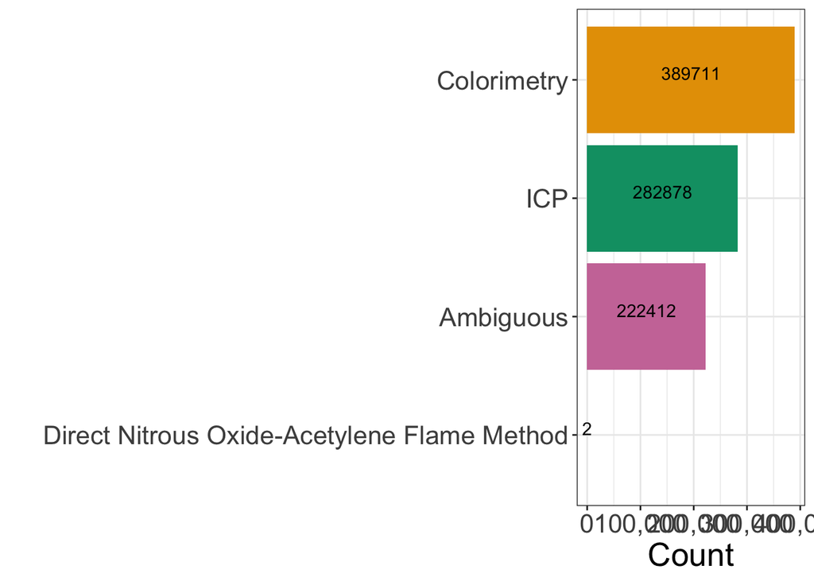

It is clear that colorimetric methods are the most common across grouped methods (at 43.543%).

However, colorimetry encompasses several different types of analytic methods that are defined by either the EPA or SM; there are also a large amount that do not clearly define which colorimetric method was used (i.e., ambiguous but some form of colorimetry):

[figure not shown]

```r
pie <- grouped_more %>%
  filter(grouped=="Colorimetry") %>%
  group_by(method_status) %>%
  summarize(count=n()) %>%
  ungroup() %>%
  mutate(method_status=ifelse(is.na(method_status), "Ambiguous Colorimetry", method_status))
pie <- pie %>% mutate(method_status = factor(x = method_status, levels = method_status)) %>%
  mutate(prop = count/sum(pie$count)) %>%
  mutate(ypos = cumsum(prop)- 0.5*prop) %>%
  mutate(legend = paste0(method_status, " (", percent(prop), ")"))

ggplot(data=pie, aes(x="", y=count, fill=legend)) +
  geom_bar(stat="identity", width=1, color="white") +
  coord_polar("y", start=0) +
  scale_fill_manual(values=c("#009E73","#E69F00","#56B4E9","#CC79A7","#0072B2","#F0E442","#D55E00")) +
  guides(fill=guide_legend(title="Colorimetry Techniques")) +
  theme_void() + # remove background, grid, numeric label
  theme(text = element_text(size = 20))
```

The ICP method is the second most common method for silica analysis, representing 31.606% of all silica samples.

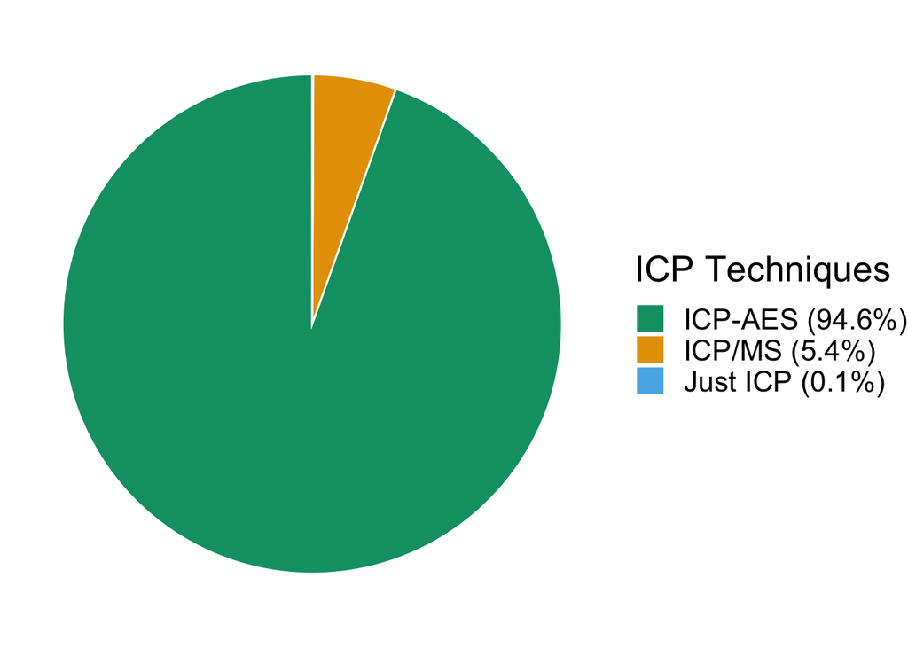

```r
pie <- grouped_more %>%
  filter(grouped=="ICP") %>%
  group_by(method_status) %>%
  summarize(count=n()) %>%
  ungroup() #%>%
#mutate(method_status=ifelse(is.na(method_status), "Ambiguous Colorimetry", method_status))
pie <- pie %>% mutate(method_status = factor(x = method_status, levels = method_status)) %>%
  mutate(prop = count/sum(pie$count)) %>%
  mutate(ypos = cumsum(prop)- 0.5*prop) %>%
  mutate(legend = paste0(method_status, " (", percent(prop), ")"))

ggplot(data=pie, aes(x="", y=count, fill=legend)) +
  geom_bar(stat="identity", width=1, color="white") +
  coord_polar("y", start=0) +
  scale_fill_manual(values=c("#009E73","#E69F00","#56B4E9","#CC79A7","#0072B2","#F0E442","#D55E00")) +
  guides(fill=guide_legend(title="ICP Techniques")) +
  theme_void() + # remove background, grid, numeric label
  theme(text = element_text(size = 20))
```

The third most prevalent aggregated method encompasses samples whose methodologies were too vague to determine how they were analyzed. 24.85% of all samples are considered ambiguous. Below is a table of all methodologies that we considered ambiguous:

```r
grouped_more %>%
  filter(grouped=="Ambiguous") %>%
  group_by(analytical_method) %>%
  summarize(count=dplyr::n()) %>%
  arrange(desc(count)) %>%
  #mutate(grouped=ifelse(is.na(grouped),"Not captured by aggreagting mechanism",grouped)) %>%
  kable(.,'html',caption='Ambiguous Methods') %>%
  kable_styling(position='center') %>%
  scroll_box(width='800px',height='500px')
```

Ambiguous Methods

| analytical_method | count |
| --- | --- |
| NA | 139646 |
| Silica, wf, DA | 11448 |
| Chloride and Silica in Lake Water | 9901 |
| silica | 7730 |
| Silicon, wu,FIA color (USGS-NYL) | 7064 |
| ANL_MTHD | 5564 |
| Unknown or Unspecified Procedure | 4998 |
| Gaseous Mercury in Air by CVAA | 4630 |
| Silica, wf, MBC (NY WSC; ALSC) | 4580 |
| Flow Injection Analysis by Lachat QuikChem for Silica | 4204 |
| Trace elements, wf, ICP/T (Ocala | 2521 |
| Used for half of methods where historical methodology may not be available. | 2225 |
| L01 | 2202 |
| Lachat FIA 31-114-27-1-A | 1696 |
| WHITLEDGE 1981 | 1674 |
| SILICA, DISSOLVED (MG/L AS SI02) | 1599 |
| HACH 8185 | 1528 |
| Historic Procedure | 1061 |
| UNKNOWN | 1001 |
| Armstrong et al. 1967 | 851 |
| Estero Bay Aquatic Preserve tributary sampling | 697 |
| Metals in Water by ICP | 609 |
| Silica by HACH DR4000 | 541 |
| Silica | 532 |
| SILICA, TOTAL (MG/L AS SI02) | 512 |
| Laboratory Procedures for Water Quality Chemical Analysis | 454 |
| Unknown | 405 |
| Legacy STORET migration; analytical procedure not specified | 390 |
| Analytical procedure not specified | 363 |
| LC3121 | 256 |
| STANDARD METHODS 4500SI - SILICA | 255 |
| Nutrient analyses from water samples | 248 |
| Not Available | 170 |
| Hawaii historic procedures for Legacy STORET | 164 |
| SiO2 | 148 |
| SM204500-SIO2C | 139 |
| Unknown Method or Procedure | 115 |
| Silica, wf, MBC (NY WSC; KECK) | 91 |
| Priority Pollutant Metals in Water | 31 |
| CL151 | 29 |
| Technicon procedure for silica | 29 |
| SILICA | 22 |
| LaMotte Silica Test Kit #4463 Model PSI | 21 |
| HACH Titration or Model DR/2010 Spectrophotometer | 16 |
| See QAPP | 14 |
| LAKE COUNTY QUALITY SYSTEMS MANUAL | 8 |
| I147287 | 6 |
| Metals, blank water, ICP | 6 |
| METALS | 4 |
| SM 4500 | 4 |
| LEGACY | 3 |
| CL064 | 2 |
| N/A Calculation | 2 |
| Silica, wf, direct AAS | 2 |
| PLA15 | 1 |

### Sample Fractions

When looking at these different grouped methodologies coupled with their fractionation we find that most samples were analyzed for the dissolved fraction of silica. In fact, only the heteropoly blue method (a colorimetric technique) had more samples that analyzed the total fraction of silica.

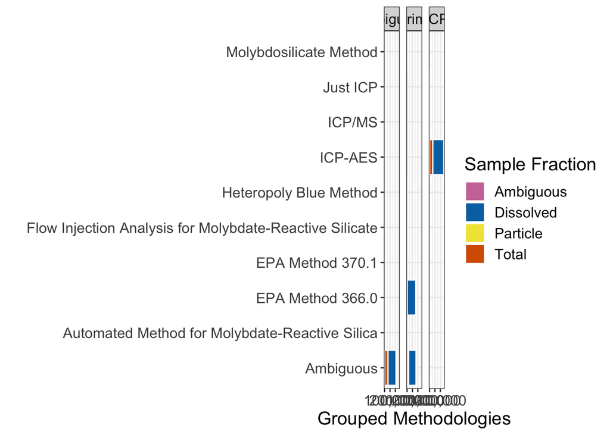

```r
grouped_more %>%
  filter(grouped%in% c("ICP","Colorimetry","Ambiguous")) %>%
  mutate(method_status=ifelse(is.na(method_status),
                              "Ambiguous", method_status)) %>%
  group_by(grouped, method_status, aquasat_fraction) %>%
  summarize(count=n()) %>%
  ggplot(aes(x=method_status,y=count,fill=aquasat_fraction)) +
  geom_bar(stat="identity", width=1, color="white") +
  theme_bw() +
  theme(text = element_text(size = 15)) +
  coord_flip() +
  ylab("Grouped Methodologies")+
  xlab("") +
  scale_fill_manual(values=c("#CC79A7","#0072B2","#F0E442","#D55E00","#009E73")) +
  guides(fill=guide_legend(title="Sample Fraction")) +
  facet_wrap(~grouped)+
  scale_y_continuous(labels = comma)
```

## How to tier silica

There is no clear way of tiering silica based on fraction if we want all tiers to be looking at the exact same thing. Instead, I suggest we only look at samples that are analyzing the dissolved fraction. The dissolved fraction makes up 79.331% of all silica samples in the Water Quality Portal, a clear sign that the majority of people monitoring silica are looking at the dissolved fraction. With this in mind, I suggest tiering silica as follows:

1. **Restrictive.** ICP (all versions). Dissolved fraction. Only water samples with an accepted value that is reasonable with logical units.
2. **Narrowed.** ICP and colorimetry (all versions). Dissolved fraction. Only water samples with an accepted value that is reasonable with logical units.
3. **Inclusive.** ICP and colorimetry (all versions), and all other *non-ambiguous* methods. Dissolved fraction. Only water samples with an accepted value that is reasonable with logical units. Currently no samples fall within this tier.
4. **Ambiguous (and therefore removed)**. Ambiguous methods. Dissolved fraction. Only water samples with an accepted value that is reasonable with logical units.

Without any additional steps other than harmonizing units and removing NA values (*I haven’t looked at whether values are reasonable*), this is how that data looks:

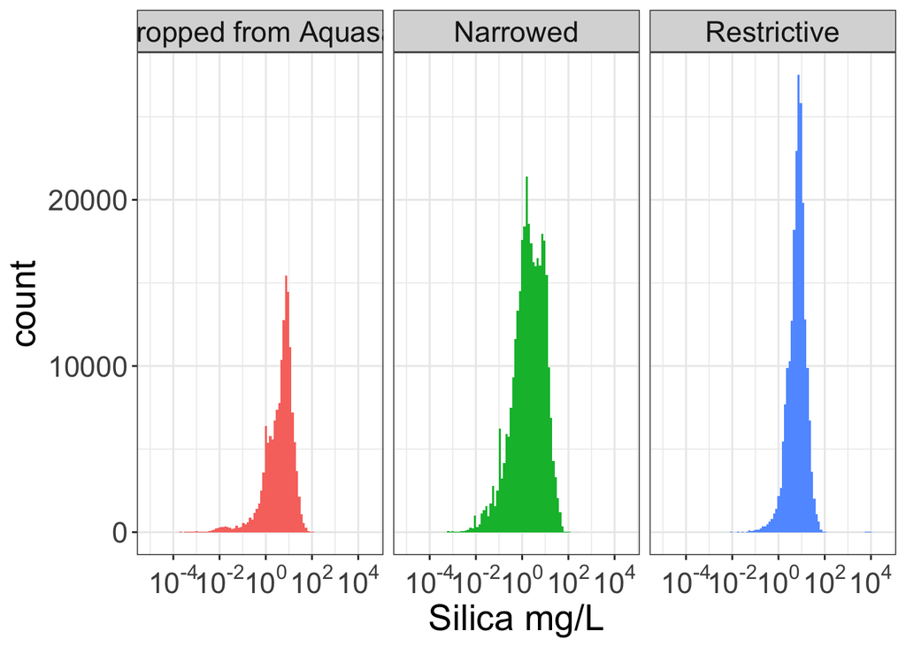

```r
#identify samples that have no meaningful data related to an NA value
no_data_samples <- grouped_more %>%
  filter(is.na(value)&is.na(units)&is.na(lab_comments)&is.na(result_comments))

#remove samples that have no values and no lab/result metadata
silica_empties_removed <- grouped_more %>%
  filter(status %in% c('Accepted','Final','Historical','Validated')) %>%
  filter(!index %in% no_data_samples$index)

vals_cleaned <- silica_empties_removed %>%
  mutate(numeric_value=as.numeric(value)) %>%
  filter(!is.na(numeric_value)) # need to work on this

# unit_disharmony <- function(d,lookup){
#   d %>%
#     anti_join(silica_lookup,by='units') %>%
#     group_by(units) %>%
#     summarize(count=n())  %>%
#     kable(.,'html',caption='The following measurements
#           were dropped because the units do not make sense') %>%
#     kable_styling() %>%
#     scroll_box(width='500px',height='400px')
# }

#Set up a lookup table so that final units are all in ug/L.
silica_lookup <- tibble(units=c('mg/L','mg/l','ppm','ug/l','ug/L','mg/m3','ppb','mg/cm3','ug/ml','mg/ml','ppt','umol/L'),
                        conversion = c(1000,1000,1000,1,1,1,1,1000000,1000,1000000,0.000001,60.080000))

#unit_disharmony(vals_cleaned,silica_lookup)

silica_harmonized <- vals_cleaned %>%
  inner_join(silica_lookup,by='units') %>%
  mutate(harmonized_value=(numeric_value*conversion)/1000,
         harmonized_unit='mg/L')

silica_tiered <- silica_harmonized %>%
  filter(aquasat_fraction=="Dissolved") %>%
  mutate(tiers=case_when(grouped=="ICP" ~ "Restrictive",
                         #grouped=="ICP/MS" ~ "Restrictive",
                         grouped=="Colorimetry" ~ "Narrowed",
                         grouped %in% c("Direct Nitrous Oxide-Acetylene Flame Method") ~ "Inclusive",
                         grouped=="Ambiguous" ~ "Dropped from Aquasat"))


# meanscores <- attributes(silica_tiered$grouped)$harmonized_value
#
# meandf <- data.frame(
#   variable = rep(names(meanscores), 4),
#   value    = rep(unname(meanscores), 6),
#   cluster  = rep(1:6, each=14)
#   )

ggplot(data=silica_tiered) +
  geom_histogram(aes(x=(harmonized_value), fill=tiers), bins=100) +
  scale_x_log10(breaks = trans_breaks("log10", function(x) 10^x),
                labels = trans_format("log10", math_format(10^.x))) +
  facet_wrap(~tiers, scales='fixed') +
  xlab('Silica mg/L') +
  theme_bw() +
  theme(legend.position = "none",
        text = element_text(size = 20))
```

## Remaining questions

```r
silica_empties_removed %>%
  mutate(numeric_value=as.numeric(value)) %>%
  filter(is.na(numeric_value)) %>%
  distinct(value,.keep_all = T) %>%
  filter(!is.na(value)) %>%
  arrange(desc(value)) %>%
  select(value) %>%
  kable(.,'html',caption='Text Inputted in Value Field') %>%
  kable_styling() %>%
  scroll_box(width='900px',height='400px')
```

Text Inputted in Value Field

| value |
| --- |

```r
mdl <- silica_empties_removed %>%
  select(index,value) %>%
  filter(grepl("0|1|2|3|4|5|6|7|8|9",value) & grepl("<", value))

mdl$num_value <- as.numeric(str_replace_all(mdl$value, c("\\<"="", "\\*" = "")))

mdl <- mdl %>%
  mutate(zero = 0,
         half = num_value/2)

mdl$epa_mdl <- with(mdl,runif(nrow(mdl),zero,half))

mdl <- select(mdl,index,epa_mdl)

# replace value field with these new values
mdls_added <- silica_empties_removed %>%
  left_join(mdl,by="index") %>%
  mutate(aquasat_value=ifelse(index %in% mdl$index, epa_mdl, value),
         aquasat_comments = ifelse(index %in% mdl$index, "Approximated, EPA LDL method", NA))
```

I’ve also played around with identifying samples that had a numeric character with an asterisk, but also provide information in the lab/result comments that suggest that they were approximated. Here I’m not dropping these samples, but instead am just flagging them as approximated in our `aquasat_comments`

```r
approx <- mdls_added %>%
  filter(!index %in% mdl$index) %>% # remove the samples that we've already approximated using the EPA method
  mutate(num_value = as.numeric(value)) %>%
  filter(is.na(num_value) &
           grepl("0|1|2|3|4|5|6|7|8|9", value) &
           (grepl("result approx|RESULT IS APPROX", lab_comments, ignore.case=T)|
              grepl("result approx|RESULT IS APPROX", result_comments, ignore.case=T ))) #select samples that are non numeric but have a number listed as well as comments related to approximation

approx$approx_value <- as.numeric(str_replace_all(approx$value, c("\\*" = "")))
approx <- select(approx,index,approx_value)

# replace value field with these new values

approx_added <- mdls_added %>%

  left_join(approx,by="index") %>%

  mutate(aquasat_value=ifelse(index %in% approx$index, approx_value, aquasat_value)) %>%

  mutate(aquasat_comments=ifelse(index %in% approx$index, "Approximate", aquasat_comments))
```

END

# True_Color

Daniel Dominguez

### ~ ~ ~ An example WQP exploratory workflow ~ ~ ~

## First step is to read in the data and make it workable, we’ll then filter the data to 1984 and beyond

```r
raw_true_color <- raw_true_color %>%
    dplyr::select(date=ActivityStartDate,
                parameter=CharacteristicName,
                parm_cd=USGSPCode,
                units=ResultMeasure.MeasureUnitCode,
                SiteID=MonitoringLocationIdentifier,
                org=OrganizationFormalName,
                org_id=OrganizationIdentifier,
                time=ActivityStartTime.Time,
                value=ResultMeasureValue,
                sample_method=SampleCollectionMethod.MethodName,
                analytical_method=ResultAnalyticalMethod.MethodName,
                particle_size=ResultParticleSizeBasisText,
                date_time=ActivityStartDateTime,
                media=ActivityMediaName,
                type=ActivityMediaSubdivisionName,
                sample_depth=ActivityDepthHeightMeasure.MeasureValue,
                sample_depth_unit=ActivityDepthHeightMeasure.MeasureUnitCode,
                fraction=ResultSampleFractionText,
                status=ResultStatusIdentifier,
                field_comments=ActivityCommentText,
                lab_comments=ResultLaboratoryCommentText,
                result_comments=ResultCommentText) %>%
  left_join(p_codes, by='parm_cd') %>%
  mutate(year=year(date),
         units = trimws(units)) %>%
  filter(year >= 1984) %>%
  rowid_to_column(.,"index")
```

## Word Matrices

Developing word matrices to be used in identifying erroneous/failed data across relevant data columns. This is Michael Meyer’s code. Essentially, we can use these matrices as justification for choosing our downstream `grepl` functions to pull out the erroneous/failed data.

```r
# Script for word frequency enumeration

gc()
memory.limit(size=28000000) # big data!

vals <- str_replace_all(raw_true_color$field_comments, c("0|1|2|3|4|5|6|7|8|9" = ""))

# First create text_in with only the abstracts
text_in <- vals

# Remove NAs
text_in <- text_in[which(is.na(text_in)==FALSE)]

# For these procedures, object needs to be of class Corpus
text0 <- Corpus(x = VectorSource(x = text_in))

# Various text processing steps.
text <-  TermDocumentMatrix(text0,
                           control =
                             list(removePunctuation = TRUE,
                                  stopwords = TRUE,
                                  tolower = TRUE,
                                  stemming = FALSE,
                                  removeNumbers = TRUE,
                                  bounds = list(global = c(1, Inf))))


# Find the frequency of certain terms that appear at least
# 20 times, and then sort them in decreasing order.
# The final outputted matrix will be saved as a CSV.
ft <- findFreqTerms(text, lowfreq = 20, highfreq = Inf)
ft_matrix <- as.matrix(text[ft,])
sorted_matrix <- sort(apply(ft_matrix, 1, sum), decreasing = TRUE)

write.csv(sorted_matrix, "C:/Users/ddomi/Documents/Code/Ross/Data/Outputs/raw_true_color_field_comments_matrix.csv")

# LAB COMMENTS

# First create text_in with only the abstracts
text_in <- raw_true_color$lab_comments

# Remove NAs
text_in <- text_in[which(is.na(text_in)==FALSE)]

# For these procedures, object needs to be of class Corpus
text0 <- Corpus(x = VectorSource(x = text_in))

# Various text processing steps.
text <-  TermDocumentMatrix(text0,
                           control =
                             list(removePunctuation = TRUE,
                                  stopwords = TRUE,
                                  tolower = TRUE,
                                  stemming = FALSE,
                                  removeNumbers = TRUE,
                                  bounds = list(global = c(1, Inf))))


# Find the frequency of certain terms that appear at least
# 20 times, and then sort them in decreasing order.
# The final outputted matrix will be saved as a CSV.
ft <- findFreqTerms(text, lowfreq = 20, highfreq = Inf)
ft_matrix <- as.matrix(text[ft,])
sorted_matrix <- sort(apply(ft_matrix, 1, sum), decreasing = TRUE)

write.csv(sorted_matrix, "C:/Users/ddomi/Documents/Code/Ross/Data/Outputs/raw_true_color_lab_comments_matrix.csv")

# RESULT COMMENTS

# First create text_in with only the abstracts
text_in <- raw_true_color$result_comments

# Remove NAs
text_in <- text_in[which(is.na(text_in)==FALSE)]

# For these procedures, object needs to be of class Corpus
text0 <- Corpus(x = VectorSource(x = text_in))

# Various text processing steps.
text <-  TermDocumentMatrix(text0,
                           control =
                             list(removePunctuation = TRUE,
                                  stopwords = TRUE,
                                  tolower = TRUE,
                                  stemming = FALSE,
                                  removeNumbers = TRUE,
                                  bounds = list(global = c(1, Inf))))


# Find the frequency of certain terms that appear at least
# 20 times, and then sort them in decreasing order.
# The final outputted matrix will be saved as a CSV.
ft <- findFreqTerms(text, lowfreq = 20, highfreq = Inf)
ft_matrix <- as.matrix(text[ft,])
sorted_matrix <- sort(apply(ft_matrix, 1, sum), decreasing = TRUE)

write.csv(sorted_matrix, "C:/Users/ddomi/Documents/Code/Ross/Data/Outputs/raw_true_color_result_comments_matrix.csv")

# VALUE COMMENTS


vals <- str_replace_all(raw_true_color$value, c("0|1|2|3|4|5|6|7|8|9" = ""))

# First create text_in with only the abstracts
text_in <- vals

# Remove NAs
text_in <- text_in[which(is.na(text_in)==FALSE)]

# For these procedures, object needs to be of class Corpus
text0 <- Corpus(x = VectorSource(x = text_in))

# Various text processing steps.
text <-  TermDocumentMatrix(text0,
                           control =
                             list(removePunctuation = TRUE,
                                  stopwords = TRUE,
                                  tolower = TRUE,
                                  stemming = FALSE,
                                  removeNumbers = TRUE,
                                  bounds = list(global = c(1, Inf))))


# Find the frequency of certain terms that appear at least
# 20 times, and then sort them in decreasing order.
# The final outputted matrix will be saved as a CSV.
ft <- findFreqTerms(text, lowfreq = 20, highfreq = Inf)
ft_matrix <- as.matrix(text[ft,])
sorted_matrix <- sort(apply(ft_matrix, 1, sum), decreasing = TRUE)

write.csv(sorted_matrix, "C:/Users/ddomi/Documents/Code/Ross/Data/Outputs/raw_true_color_values_matrix.csv")
```

## Initial Data Cleaning Steps

First off, let’s focus our data set to “water” samples (as done in original AquaSat). Then we can remove any samples from our data set that failed, or don’t have enough lab metadata to make assumptions about the values presented. (In the future, these `grepl` functions can be based on the word matrices we just produced upstream!)

```r
true_color_no_data_samples <- raw_true_color %>%
  filter(is.na(value)&is.na(units)&is.na(lab_comments)&is.na(result_comments)) #identify samples that have no meaningful data related to an NA value

true_color_fails_removed <- raw_true_color %>%
  filter(media=="Water") %>%
  filter(status %in% c('Accepted','Final','Historical','Validated')) %>%
  filter(!grepl("fail|suspect|error|beyond accept|interference|questionable|outside of accept|problem|contaminat|improper|violation|invalid|unable|no test|cancelled|instrument down|no result|time exceed|not accept|QC EXCEEDED",field_comments,ignore.case=T)|is.na(field_comments)) %>% #no failure-related field comments, slightly different list of words than lab and result list (not including things that could be used to describe field conditions like "warm", "ice", etc.)
  filter(!grepl("fail|suspect|error|beyond accept|interference|questionable|outside of accept|problem|contaminat|improper|warm|violation|invalid|unable|no test|cancelled|instrument down|no result|time exceed|not accept|QC EXCEEDED|not ice|ice melt|PAST HOLDING TIME|beyond|exceeded|failed|exceededs",lab_comments,ignore.case=T)|is.na(lab_comments)) %>% #no failure-related lab, should we remove controls comments
  filter(!grepl("fail|suspect|error|beyond accept|interference|questionable|outside of accept|problem|contaminat|improper|warm|violation|invalid|unable|no test|cancelled|instrument down|no result|time exceed|not accept|QC EXCEEDED|not ice|ice melt|PAST HOLDING TIME|null|unavailable|exceeded|rejected",result_comments,ignore.case=T)|is.na(result_comments)) %>% #no failure-related result comments
  filter(!grepl("fail|suspect|error|beyond accept|interference|questionable|outside of accept|problem|contaminat|improper|warm|violation|invalid|unable|no test|cancelled|instrument down|no result|time exceed|not accept|QC EXCEEDED|not ice|ice melt|PAST HOLDING TIME",value,ignore.case=T)|is.na(value)) %>% #no failure-related values
  filter(!index %in% true_color_no_data_samples$index) #remove samples that have no values and no lab/result metadata
```

### The result of dropping the data based on various words in the lab, field, result comments.

```r
print(paste('We kept', round(nrow(true_color_fails_removed)/nrow(raw_true_color)*100,2),'% of samples, because the method used did not make sense. These methods are:'))
```

[output not shown]

# Next we begin filtering the results to exclude qualitative results this is because there are various color specifications (such as green, yellow, brown, etc.) that altough give an estimation of apparent color do not provide a relevant scale which is comparable to the other apparent/ true color scales.

```r
true_color_fails_removed$value <- gsub("[a-zA-Z]","",true_color_fails_removed$value)# this removes the qualitative results from the dataset

testsamples<-true_color_fails_removed %>%
  count(value) # Create a dataframe from values to identify special characters and see if they're worth keeping

true_color_vals_filtered <- true_color_fails_removed %>%
  filter(!grepl("*<|#|>| |-|,|/",value,ignore.case=F)|is.na(value)) #no failure-related values|

testsamples<-true_color_vals_filtered %>%
  count(value) # rerun to make sure special characters were removed, still having a problem removing asterisk without removing valied values

# write_feather(true_color_vals_filtered,"../data/true_color_vals_filtered.feather")
#
# gc()
```

### The result of dropping all values that are qualitative and not quantitative is

```r
print(paste('We kept', round(nrow(true_color_vals_filtered)/nrow(true_color_fails_removed)*100,2),'% of samples, because the values were qualitative and not quantitative.'))
```

```
## [1] "We kept 100 % of samples, because the values were qualitative and not quantitative."
```

### Since we kept the majority of the data, exclusion of qualitative data should not be impactful for the rest of the dataset.

## There are three parameter classifications when there should be two Apparent/True Color, the third “Color” classification needs to be further explore so for now we’ll split the data into three dataframes.

```r
# true_color_vals_filtered<- read_feather("C:/Users/ddomi/Documents/Code/Ross/Data/true_color_vals_filtered.feather")

gc()
```

```
##              used    (Mb) gc trigger  (Mb) limit (Mb)   max used    (Mb)
## Ncells   18810445  1004.6   28534627  1524         NA   28534627  1524.0
## Vcells 2090900046 15952.4 3201298113 24424      65536 2759809089 21055.7
```

```r
Truecolor_Apparent<- true_color_vals_filtered %>%
  filter(parameter== "Apparent color")

Truecolor_Color<- true_color_vals_filtered %>%
  filter(parameter== "Color")

Truecolor_True<- true_color_vals_filtered %>%
  filter(parameter== "True color")

Parameter_count<-true_color_vals_filtered %>%
  count(parameter) %>%
  mutate(paramer_percentage=n/sum(n)*100)
```

### The good news is that the true color measurments are the significant portion of the data, with apparent color also being the other significant variable that we know how to deal with, while color is only a small fraction of the data

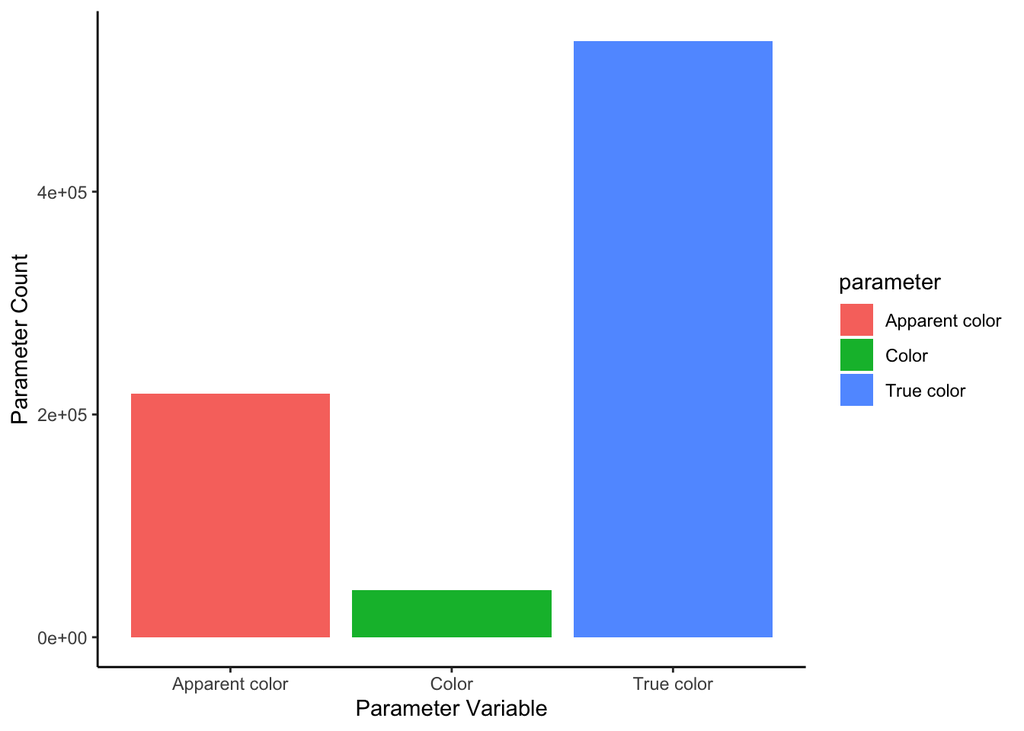

```r
ggplot(true_color_vals_filtered)+
  geom_bar(aes(parameter, fill=parameter))+
  theme_classic()+
  labs(x="Parameter Variable",
       y="Parameter Count")
```

```r
kable(Parameter_count, "html") %>%
  kable_styling("striped", full_width = F)
```

| parameter | n | paramer_percentage |
| --- | --- | --- |
| Apparent color | 218821 | 27.472163 |
| Color | 42352 | 5.317136 |
| True color | 535346 | 67.210701 |

## Next we will analyze the analytical and sample methods to see how the samples are being analyzed and proccessed

```r
Apparent_methods<- Truecolor_Apparent %>%
  count(analytical_method)

Color_methods<- Truecolor_Color %>%
  count(analytical_method)

Truecolor_methods<- Truecolor_True %>%
  count(analytical_method)
```

### First we will see how the unique analytical methods are being analyzed. Unfortunately it seems like a little over a third of the data is being lost do to no analytical method being present.

```r
Truecolor_uniquemethods<- true_color_vals_filtered %>%
  count(analytical_method)%>%
  mutate(samp_perc= n/sum(n)*100)

Truecolor_samplemethods<- true_color_vals_filtered %>%
  count(sample_method) %>%
  mutate(samp_perc= n/sum(n)*100)
```

```r
kable(Truecolor_uniquemethods, "html") %>%
  kable_styling("striped", full_width = F)
```

| analytical_method | n | samp_perc |
| --- | --- | --- |
| 10-308-00-1 A ~ Determination of Color in Water | 32 | 0.0040175 |
| 2120 B ~ Color in Water by Visual Comparison | 195170 | 24.5028681 |
| 2120 C ~ Color in Water by Spectrophotometry | 48072 | 6.0352609 |
| 2120 E ~ Color in Water Using the ADMI Method | 5766 | 0.7238999 |
| 2320 B ~ Alkalinity by Gran Titration | 1 | 0.0001255 |
| Analytical procedure not specified | 3 | 0.0003766 |
| Apparent color (EPA110.2 /DODEC) | 82 | 0.0102948 |
| Apparent color (StdMeth /DODEC) | 209 | 0.0262392 |
| Apparent Color, Hach Color Wheel Method | 607 | 0.0762066 |
| Color | 6542 | 0.8213238 |
| COLOR | 3475 | 0.4362733 |
| Color - Pt/Co units | 5326 | 0.6686595 |
| Color - Spectrophotometric Single Wavelength Method | 6912 | 0.8677759 |
| Color - Visual Comparison Method | 6186 | 0.7766293 |
| Color (EPA) | 418 | 0.0524783 |
| COLOR (PLATINUM-COBALT UNITS) | 6707 | 0.8420389 |
| COLOR 345 C | 10164 | 1.2760524 |
| COLOR 345 F .45 | 12615 | 1.5837664 |
| COLOR 440 F .22 | 394 | 0.0494652 |
| Color Analysis Using Platinum/Cobalt | 73866 | 9.2736018 |
| Color by Calculating ADMI Values | 1704 | 0.2139309 |
| Color by Spectrophotometric Analysis | 246 | 0.0308844 |
| Color in the Field by Unknown Limnology Color Chart | 31 | 0.0038919 |
| Color in Water by Spectrophotometry | 5 | 0.0006277 |
| Color in Water by Spectrophotometry Modified | 8009 | 1.0055002 |
| Color in Water by Visual Comparison | 39 | 0.0048963 |
| Color, APHA Platinum-Cobalt | 8270 | 1.0382678 |
| Color, True | 490 | 0.0615177 |
| Color, wf, visual comparison | 21488 | 2.6977385 |
| COLOR,APPARENT(UNFILTERED SAMPLE) PLAT-COB UNITS | 489 | 0.0613921 |
| DEP Field Analytical Procedures | 2 | 0.0002511 |
| EPA110.2 | 165 | 0.0207151 |
| Estero Bay Aquatic Preserve tributary sampling | 692 | 0.0868780 |
| Field measurement/observation, generic method | 14 | 0.0017576 |
| Field Office procedures | 387 | 0.0485864 |
| General Listing of Field and Lab Analytical Procedures for Manatee County | 5118 | 0.6425459 |
| HACH KIT | 92 | 0.0115503 |
| I1250 | 1629 | 0.2045149 |
| Laboratory Procedures for Water Quality Chemical Analysis | 3612 | 0.4534732 |
| LAKE COUNTY QUALITY SYSTEMS MANUAL | 1130 | 0.1418673 |
| Lake Trafford | 213 | 0.0267414 |
| LaMotte Smart 2 Colorimeter | 68 | 0.0085371 |
| LEGACY | 4166 | 0.5230258 |
| Legacy STORET migration; analytical procedure not specified | 277 | 0.0347763 |
| Measurement of Water Color | 1220 | 0.1531665 |
| N/A Calculation | 69 | 0.0086627 |
| Other of Unknown Procedure | 695 | 0.0872547 |
| Other or Unknown Procedure | 10306 | 1.2938800 |
| QA Plan #900456 | 4098 | 0.5144887 |
| SM182120B | 340 | 0.0426857 |
| SM2120C | 6268 | 0.7869241 |
| STANDARD METHODS 2120B COLOR BY VISUAL | 2765 | 0.3471355 |
| Standard Methods for the Examination of Water and Wastewater | 6190 | 0.7771315 |
| To be updated | 207 | 0.0259881 |
| USEPA Methods for Chemical Analysis or Water and Wastewater; EPA 600/4-79-020 | 2412 | 0.3028176 |
| NA | 321066 | 40.3086430 |

```r
kable(Truecolor_samplemethods, "html") %>%
  kable_styling("striped", full_width = F)
```

| sample_method | n | samp_perc |
| --- | --- | --- |
| **Not Recorded** | 66 | 0.0082861 |
| 10 or more equal width verticals, equal non-iso transit rate limited by velocity | 24 | 0.0030131 |
| ADEM SOPs-2000 Series-Surface Water | 1884 | 0.2365292 |
| AMBIENT AND VRAP SAMPLING PROCEDURES | 225 | 0.0282479 |
| Ambient Water Quality Monitoring QAPP and SOP | 160 | 0.0200874 |
| Aquatic Invasive Species (AIS) Early Detection Monitoring (2011) | 1 | 0.0001255 |
| Automated Water Sampler | 8 | 0.0010044 |
| Bacteria Sampling | 178 | 0.0223472 |
| Bank - Churn | 21 | 0.0026365 |
| Bank - Dipper/Churn | 133 | 0.0166977 |
| Bank - Direct Method | 4 | 0.0005022 |
| BB-002 | 8706 | 1.0930059 |
| BB-005 | 1465 | 0.1839253 |
| BB-006 | 2311 | 0.2901375 |
| Bedload, multiple equal width increment (MEWI) | 1 | 0.0001255 |
| Bio-Chem Lab Standard Grab Sample Procedure | 72 | 0.0090393 |
| Boat | 711 | 0.0892634 |
| Boat - Churn | 8 | 0.0010044 |
| Boat - Direct Method | 1 | 0.0001255 |
| Boat - Kemmerer/Churn | 1 | 0.0001255 |
| Brass Kemmerer sample | 202 | 0.0253603 |
| Bridge - Rope/Churn | 253 | 0.0317632 |
| Bridge Downstream | 95 | 0.0119269 |
| Bridge Upstream | 151 | 0.0189575 |
| CENTER FOR FRESHWATER BIOLOGY STANDARD OPERATING PROCEDURES | 441 | 0.0553659 |
| CLMN - Mason Jar Sampler 1990-1994 | 1 | 0.0001255 |
| CLMN - Van Dorn Sampler 1995 | 12 | 0.0015066 |
| COLLECT1 | 296 | 0.0371617 |
| Collier County Water Sampling Collection Procedure | 4756 | 0.5970981 |
| Columbus Water Works Sample Collection SOP | 373 | 0.0468288 |

[output cut: 177 more lines]

### Now we create a classification groups based on analytical methods to sort samples into (Visual, Spectrophotogrametry, photogrametry)

```r
gc()
```

```
##              used    (Mb) gc trigger  (Mb) limit (Mb)   max used    (Mb)
## Ncells   18812744  1004.8   28534627  1524         NA   28534627  1524.0
## Vcells 1553707757 11853.9 3201298113 24424      65536 2759809089 21055.7
```

```r
visual_methods<-tibble(group=c("visual"),
                       analytical_method=c("2120 B ~ Color in Water by Visual Comparison",
                                 "Color - Visual Comparison Method",
                                 "Color in Water by Visual Comparison",
                                 "STANDARD METHODS 2120B COLOR BY VISUAL",
                                 "2320 B ~ Alkalinity by Gran Titration"))

Specphoto_methods<-tibble(group=c("Spectrophotometry"),
                       analytical_method=c("2120 C ~ Color in Water by Spectrophotometry",
                                 "Color - Spectrophotometric Single Wavelength Method",
                                 "Color by Spectrophotometric Analysis",
                                 "Color in Water by Spectrophotometry Modified",
                                 "Color in Water by Spectrophotometry"))

photo_methods<-tibble(group=c("Photometry"),
                       analytical_method=c("2120 E ~ Color in Water Using the ADMI Method",
                                 "Color by Calculating ADMI Values",
                                 "Color, wf, visual comparison",
                                 "Color by Calculating ADMI Values"))

Ambigous_methods<-tibble(group=c("Ambigous"),
                       analytical_method=c("10-308-00-1 A ~ Determination of Color in Water",
                                 "Analytical procedure not specified",
                                 "Color",
                                 "COLOR",
                                 "Color - Pt/Co units",
                                 "COLOR (PLATINUM-COBALT UNITS)",
                                 "COLOR 345 C",
                                 "COLOR 345 F .45",
                                 "COLOR 440 F .22",
                                 "Color Analysis Using Platinum/Cobalt",
                                 "COLOR IN WATERS",
                                 "Color, APHA Platinum-Cobalt",
                                 "Color, True",
                                 "DEP-SOP-NU-094",
                                 "EPA110.2",
                                 "Estero Bay Aquatic Preserve tributary sampling",
                                 "Field measurement/observation, generic method",
                                 "Field Office procedures",
                                 "FIIR - NPHL",
                                 "Laboratory Procedures for Water Quality Chemical Analysis",
                                 "LAKE COUNTY QUALITY SYSTEMS MANUAL",
                                 "Lake Trafford",
                                 "LEGACY",
                                 "Legacy STORET migration; analytical procedure not specified",
                                 "Measurement of Water Color",
                                 "N/A Calculation",
                                 "Other of Unknown Procedure",
                                 "Other or Unknown Procedure",
                                 "SM182120B",
                                 "SM2120C",
                                 "Standard Methods for the Examination of Water and Wastewater",
                                 "To be updated",
                                 "USEPA Methods for Chemical Analysis or Water and Wastewater; EPA 600/4-79-020",
                                 NA,
                                 "Color (EPA)",
                                 "Field - Color",
                                 "ANALYSIS OF COLOR IN WATERS - MODIFIED LACHAT METHOD 10-308-00-1-A",
                                 "Apparent color (EPA110.2 /DODEC)",
                                 "Apparent color (StdMeth /DODEC)",
                                 "Apparent Color, Hach Color Wheel Method",
                                 "Color in the Field by Unknown Limnology Color Chart",
                                 "Color, APHA Platinum-Cobalt",
                                 "COLOR,APPARENT(UNFILTERED SAMPLE) PLAT-COB UNITS",
                                 "DEP Field Analytical Procedures",
                                 "General Listing of Field and Lab Analytical Procedures for Manatee County",
                                 "HACH KIT",
                                 "I1250",
                                 "LAKE COUNTY QUALITY SYSTEMS MANUAL",
                                 "LaMotte Smart 2 Colorimeter",
                                 "LEGACY",
                                 "Legacy STORET migration; analytical procedure not specified",
                                 "Other of Unknown Procedure",
                                 "QA Plan #900456" ))

methods_stacked<- rbind(visual_methods, Specphoto_methods, photo_methods, Ambigous_methods)
```

#### Now join the new method classifications and we will drop the datat with no analytical methods since we can not be sure how the data is being analyzed to sort into the classifcations for inslusion in the final aquasat dataset.

```r
true_color_method_groups<- left_join(true_color_vals_filtered, methods_stacked, by="analytical_method")

true_color_goup_NA<- true_color_method_groups %>%
  filter(is.na(group))### Check to make sure onbservations all have group vals

true_color_ambigous_methods_dropped<-true_color_method_groups %>%
  filter(!group=="Ambigous")### Drop the ambigous methods since we want to keep high quality data, will have to check to make sure that we do want to drop these vals

print(paste('We kept', round(nrow(true_color_ambigous_methods_dropped)/nrow(true_color_vals_filtered)*100,2),'% of samples, because the method  could not be classified into an apparent/true color standard:'))
```

```
## [1] "We kept 37.42 % of samples, because the method  could not be classified into an apparent/true color standard:"
```

```r
rm(true_color_vals_filtered,Truecolor_Apparent, Truecolor_Color,Truecolor_True )
```

### Now we rerun and filter out nonsensical methods like filtered methods for apparent color that can’t exist becasue apparent color is nonfiltered while checking to make sure we dropped everything else

```r
Apparent_methods_check<- true_color_ambigous_methods_dropped %>%
  filter(parameter== "Apparent color") %>%
  count(analytical_method) %>%
  mutate(percent= n/sum(n)*100)

Color_methods_check<- true_color_ambigous_methods_dropped %>%
    filter(parameter== "Color") %>%
  count(analytical_method)%>%
  mutate(percent= n/sum(n)*100)

Truecolor_methods__check<- true_color_ambigous_methods_dropped %>%
    filter(parameter== "True color") %>%
  count(analytical_method)%>%
  mutate(percent= n/sum(n)*100)
```

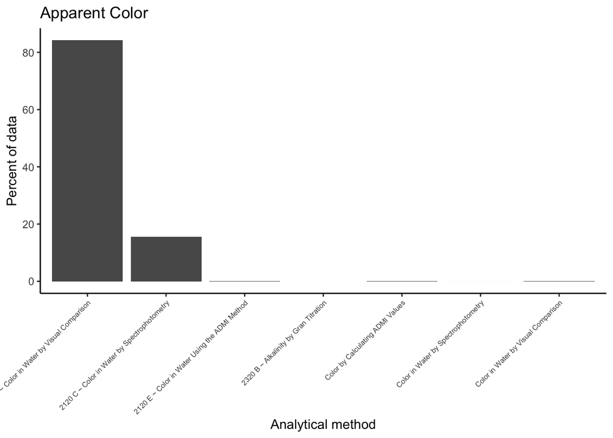

```r
ggplot(Apparent_methods_check)+
  geom_col(aes(x=analytical_method, y=percent))+
  theme_classic()+
  labs(x="Analytical method",
       y="Percent of data",
       title = "Apparent Color")+
  theme(axis.text.x = element_text(angle=45, hjust=1, size = 6))
```

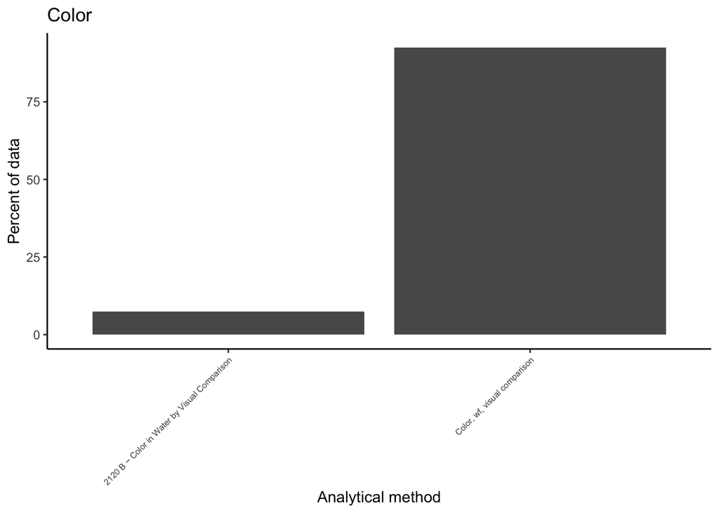

```r
ggplot(Color_methods_check)+
  geom_col(aes(x=analytical_method, y=percent))+
  theme_classic()+
  labs(x="Analytical method",
       y="Percent of data",
       title = "Color")+
  theme(axis.text.x = element_text(angle=45, hjust=1, size = 6))
```

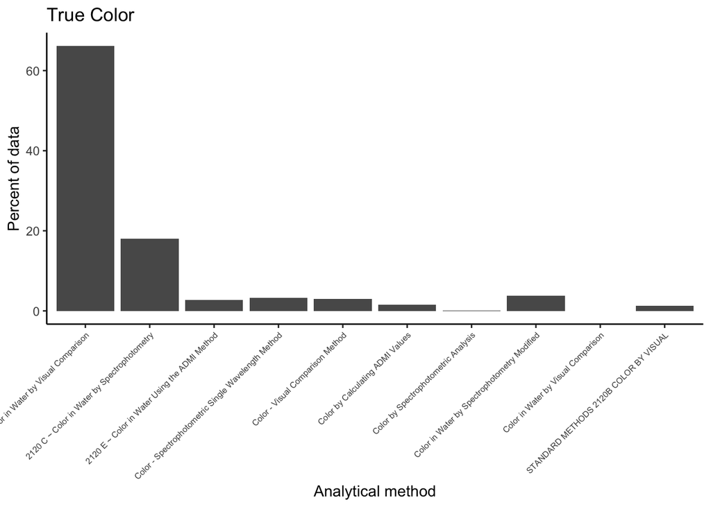

```r
ggplot(Truecolor_methods__check)+
  geom_col(aes(x=analytical_method, y=percent))+
  theme_classic()+
  labs(x="Analytical method",
       y="Percent of data",
       title = "True Color")+
  theme(axis.text.x = element_text(angle=45, hjust=1, size = 6))
```

## The next step is to drop methods that can not occur with specific parameter classification i.e apparent color can only be measured using visual methods because all other standard require the sample to be filtered before measuring and therefore making it apparent color. Luckily the Color parameter classification comes with the USGS P-code so we can be sure that these are actually True color measurements (00080, Physical Color, water, filtered, platinum cobalt units Agree, Dissolved, Color, PCU)

## Should we change these Apparent Color to True Color or not since we cant be 100% sure what they logged here????

```r
Apparent_nonsensical_methods_dropped <- true_color_ambigous_methods_dropped %>%
  filter(parameter=="Apparent color") %>%
  filter(!grepl("2120 C ~ Color in Water by Spectrophotometry|2120 E ~ Color in Water Using the ADMI Method|2320 B ~ Alkalinity by Gran Titration|Color - Spectrophotometric Single Wavelength Method|Color by Calculating ADMI Values|Color by Spectrophotometric Analysis|Color in Water by Spectrophotometry|Color in Water by Spectrophotometry Modified", analytical_method, ignore.case = T))

Apparent_nonsensical_methods<- true_color_ambigous_methods_dropped %>%
  filter(parameter=="Apparent color")

Color_nonsensical_methods_dropped<- true_color_ambigous_methods_dropped %>%
    filter(parameter== "Color")

Truecolor_nonsensical_methods_dropped<- true_color_ambigous_methods_dropped %>%
    filter(parameter== "True color")

Water_Color_final_filter<- rbind(Apparent_nonsensical_methods_dropped,
                          Color_nonsensical_methods_dropped,
                          Truecolor_nonsensical_methods_dropped)
```

```r
print(paste('We kept', round(nrow(Apparent_nonsensical_methods_dropped)/nrow(Apparent_nonsensical_methods)*100,2),'% of samples, because the method  could  be classified into an apparent color standard that makes sense:'))
```

```
## [1] "We kept 84.27 % of samples, because the method  could  be classified into an apparent color standard that makes sense:"
```

## Lastly we filter by non-sensical units only keeping those that make sense which are Platinum Cobalt Units and ADMI for the 2120E standard

```r
water_color_units<-Water_Color_final_filter %>%
  count(units)  ### looks like most of the units at this point are in PCU, so now we can drop the rest of the units that dont make sense, we have to make another set of tibbles because using grepl it will drop PCU units when we filte CU

water_color_units_filetered<- Water_Color_final_filter %>%
    filter(!grepl("AU|CU|mg/l|None|pt|units/cm|uS/cm", units, ignore.case = T))

Senseless_unit_vals<- tibble(unit_type=c("drop"),
                             units= c("AU","CU","mg/l","None","pt","units/cm","uS/cm"))

sense_unit_vals<- tibble(unit_type= c("keep"),
                         units=c("ADMI",
                         "PCU"))


units<- rbind(Senseless_unit_vals,sense_unit_vals)

Water_color_unit_drop<- left_join(Water_Color_final_filter, units, by= "units") %>%
  filter(!unit_type== "drop")

Water_color_unit_check<- Water_color_unit_drop %>%
  count(units)
```

### Looks like we kept the vast majority of data at this stage of the filtering

```r
print(paste('We kept', round(nrow(Water_color_unit_drop)/nrow(Water_Color_final_filter)*100,2),'% of samples, because the units made sense for Apparent/True Color measurements:'))
```

```
## [1] "We kept 94.48 % of samples, because the units made sense for Apparent/True Color measurements:"
```

## Last step check for numerical values

```r
vals_cleaned <- Water_color_unit_drop %>%
  mutate(value=as.numeric(value)) %>%
  filter(!is.na(value))

Vals_cleaned_classification<- vals_cleaned %>%
  group_by(parameter,group) %>%
  count()%>%
  mutate(percent= n/sum(n)*100)
```

```r
print(paste('We kept', round(nrow(vals_cleaned)/nrow(raw_true_color)*100,2),'% of samples after all the cleaning steps'))
```

```
## [1] "We kept 31.72 % of samples after all the cleaning steps"
```

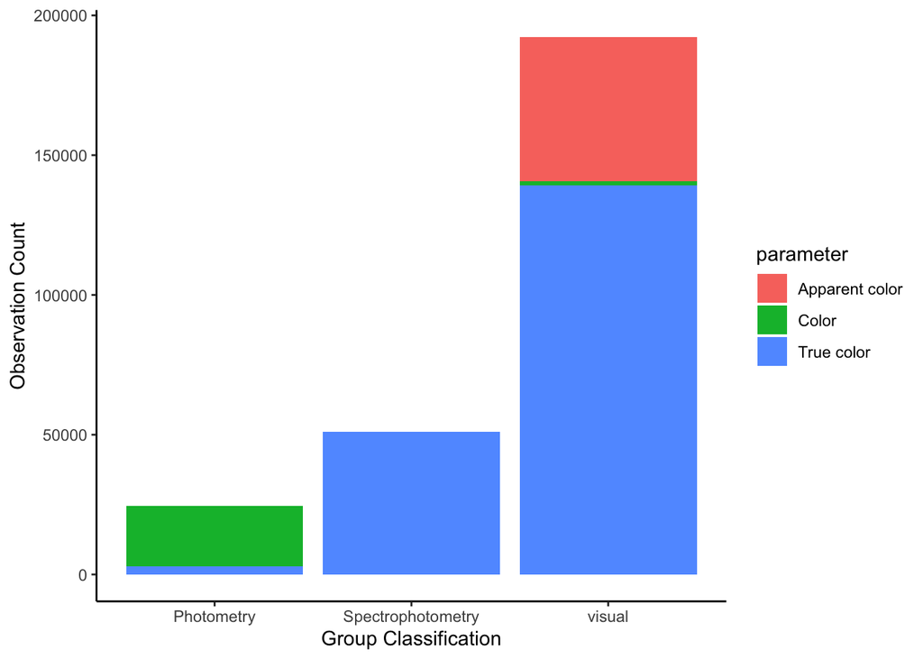

```r
ggplot(Vals_cleaned_classification)+
  geom_col(aes(x=group, y=n, fill=parameter))+
  theme_classic()+
  labs(x="Group Classification",
       y="Observation Count")
```

# TSS

## Aggregating

```r
raw_tss <- raw_tss %>%
  dplyr::select(date = ActivityStartDate,
                parameter = CharacteristicName,
                units = ResultMeasure.MeasureUnitCode,
                SiteID = MonitoringLocationIdentifier,
                org = OrganizationFormalName,
                org_id = OrganizationIdentifier,
                time = ActivityStartTime.Time,
                value = ResultMeasureValue,
                sample_method = SampleCollectionMethod.MethodName,
                analytical_method = ResultAnalyticalMethod.MethodName,
                particle_size = ResultParticleSizeBasisText,
                date_time = ActivityStartDateTime,
                media = ActivityMediaName,
                sample_depth = ActivityDepthHeightMeasure.MeasureValue,
                sample_depth_unit = ActivityDepthHeightMeasure.MeasureUnitCode,
                fraction = ResultSampleFractionText,
                status = ResultStatusIdentifier) %>%
  # Remove trailing white space in labels (Is this still necessary?)
  mutate(units = trimws(units)) %>%
  #Keep only samples that are water samples
  filter(media == "Water")
```

All parameter and unit combinations

| units | count |
| --- | --- |
| mg/l | 4148582 |
| % | 369183 |
| NA | 299388 |
| counts/mL | 36076 |
| g/l | 10024 |
| ppm | 7851 |
| count/l | 5550 |
| ug/l | 611 |
| tons/day | 517 |
| g | 313 |
| None | 260 |
| % sediment | 1 |
| count | 1 |
| deg C | 1 |
| NTU | 1 |

All analytical methods and their count

| analytical_method | count |
| --- | --- |
| NA | 1276344 |
| 2540 D ~ Total Suspended Solids in Water | 918887 |
| Non-Filterable Residue - TSS | 763645 |
| Residue by Evaporation and Gravimetric | 272814 |
| Sediment conc by filtration | 172893 |
| Sus solids, wat, 105C,wt (NWQL) | 106983 |
| analyticTSS_101 | 105332 |
| Wet sieve | 93206 |
| Sediment conc from size analysis | 92132 |
| analyticTSS_GRAVIMETRIC; DRIED AT 103-105 C | 84773 |
| Volatile Residue | 69329 |
| Computation by NWIS algorithm | 68423 |
| 160.2 M ~ Total Suspended Solids | 67398 |
| Sediment conc by evaporation | 56125 |
| SM2540D | 39097 |
| Residue | 36187 |
| Sediment particle count bin size | 36076 |
| 160.2 | 33936 |
| RESIDUE, TOTAL NONFILTRABLE (MG/L) | 29870 |
| V A tube | 27478 |
| Not Available | 25826 |
| SM 2540D | 25010 |
| Dry sieve | 22369 |
| EPA 160.4 | 22127 |
| UNKNOWN | 21621 |
| Unkn Lab Proc | 19953 |
| N/A Calculation | 19393 |
| SM 2540 D | 19299 |
| Laser diffraction, BC LS 13-320 | 17900 |
| UNKOWN | 17337 |

[output cut: 213 more lines]

```r
# There are a lot of parameter codes so we are just going to use a grepl command
# with key words that definitely disqualify the sample

nonsensical_tss_methods <- raw_tss %>%
  filter(grepl(pattern = "Oxygen|Nitrogen|Ammonia|Metals|E. coli|Carbon|Anion|Cation|Phosphorus|Silica|PH|HARDNESS|Nutrient|Turbidity|Temperature|Nitrate|Conductance|Alkalinity|Chlorophyll",
               x = analytical_method,
               ignore.case = T))

tss_filtered <- raw_tss %>%
  filter(!analytical_method %in% nonsensical_tss_methods$analytical_method)

print(
  paste("We dropped",
        round(nrow(nonsensical_tss_methods) / nrow(raw_tss) * 100,2),
        '% of samples, because the method used did not make sense. These methods are:')
)
```

```
## [1] "We dropped 0.37 % of samples, because the method used did not make sense. These methods are:"
```

```r
# Nice function for printing long vectors horizontally separated by dash
p(unique(nonsensical_tss_methods$analytical_method),
  wrap = "",
  sep = " - ")
```

```
## [1] "Nitrate, Total N, Total P, Si, TSS, Ammonia N, Chlorophyll 'a'; - 4500 NH3 E ~ Ammonia in Water by Selective Electrode Method (Known Addition) - 10200 H ~ Chlorophyll a-b-c Determination - Alkalinity in Water by Titration - 200.7 W  ~ Metals in Water by ICP-AES - pH - 200.8 W  ~ Metals in Wa…
```

### TSS depth of sampling

```r
# Define a depth lookup table to convert all depth data to meters.
depth_lookup <- tibble(sample_depth_unit = c("cm", "feet", "ft", "in", "m",
                                             "meters", "None"),
                       depth_conversion = c(1 / 100, .3048, .3048, 0.0254,
                                            1, 1, NA))

# Join depth lookup table to tss data
tss_depth <- inner_join(x = raw_tss,
                        y = depth_lookup,
                        by = c("sample_depth_unit")) %>%
  # Some depth measurements have negative values (assume that is just preference)
  # I also added .01 meters because many samlples have depth of zero assuming
  # they were taken directly at the surface
  mutate(sample_depth = as.numeric(sample_depth),
         harmonized_depth = abs(sample_depth * depth_conversion) + .01)
# We lose lots of data by keeping only data with depth measurements
print(paste("If we only kept samples that had depth information we would lose",
            round((nrow(raw_tss) - nrow(tss_depth)) / nrow(raw_tss) * 100, 1),
            "% of samples"))
```

```
## [1] "If we only kept samples that had depth information we would lose 70.2 % of samples"
```

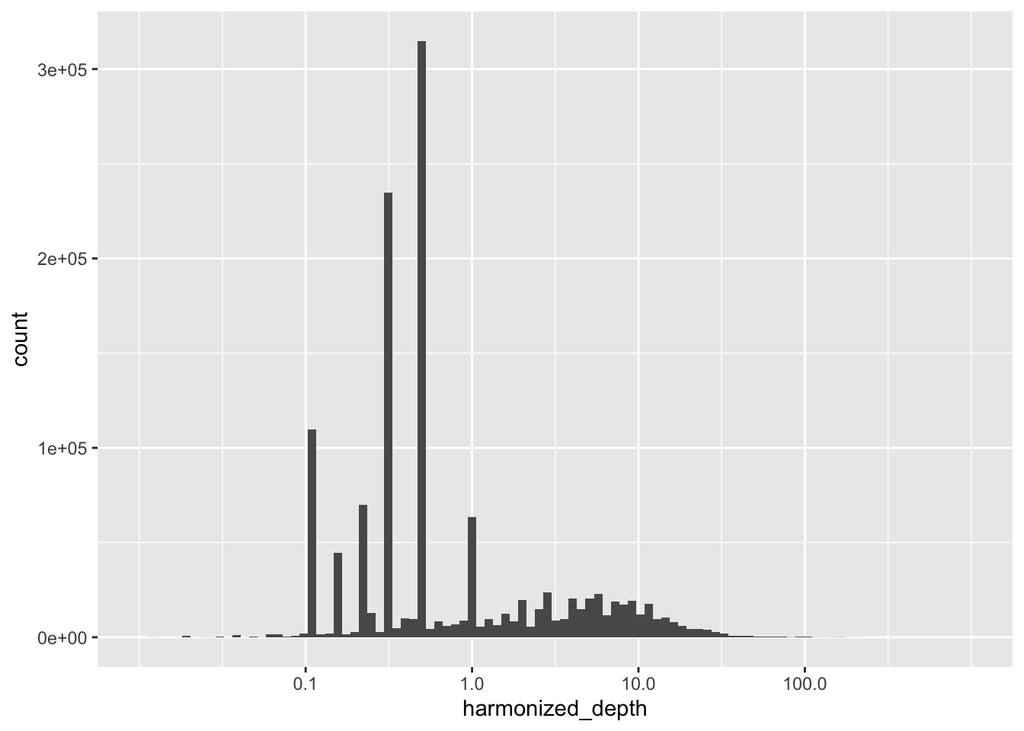

```r
ggplot(tss_depth, aes(x = harmonized_depth)) +
  geom_histogram(bins = 100) +
  scale_x_log10(limits = c(0.01, 10^3), breaks = c(.1, 1, 10, 100))
```

## TSS Unit Harmonization

### TSS disharmony

#### TSS particle size fractionation

```r
# Select only units for %
tss_perc <- raw_tss %>%
  filter(units == "%")

# Look at the breakdown of particle sizes
tss_perc %>%
  group_by(particle_size) %>%
  summarize(count = n()) %>%
  kable(.,
        "html",
        caption = "All particle size fractions and their count") %>%
  kable_styling() %>%
  scroll_box(width = "600px", height = "400px")
```

All particle size fractions and their count

| particle_size | count |
| --- | --- |
| < 0.001 mm | 728 |
| < 0.0015 mm | 14 |
| < 0.002 mm | 4970 |
| < 0.003 mm | 14 |
| < 0.004 mm | 5412 |
| < 0.006 mm | 14 |
| < 0.008 mm | 3978 |
| < 0.012 mm | 14 |
| < 0.016 mm | 5088 |
| < 0.02 mm | 13 |
| < 0.024 mm | 13 |
| < 0.031 mm | 3107 |
| < 0.038 mm | 16 |
| < 0.045 mm | 12 |
| < 0.053 mm | 16 |
| < 0.0625 mm | 221505 |
| < 0.062mm | 188 |
| < 0.075 mm | 53 |
| < 0.088 mm | 14 |
| < 0.09 mm | 136 |
| < 0.106 mm | 49 |
| < 0.125 mm | 28449 |
| < 0.15 mm | 39 |
| < 0.18 mm | 125 |
| < 0.212 mm | 39 |
| < 0.25 mm | 27689 |
| < 0.3 mm | 33 |
| < 0.35 mm | 14 |
| < 0.355 mm | 100 |
| < 0.425 mm | 9 |

[output cut: 66 more lines]

```r
# Keep only the sand fraction data (~50% of the data)
sand.harmonized  <- tss_perc %>%
  filter(particle_size %in%  c("< 0.0625 mm","sands")) %>%
  mutate(conversion = NA,
         harmonized_parameter = "p.sand",
         harmonized_value = value,
         harmonized_unit = "%")
```

#### TSS dropping bad units

```r
# Make a tss lookup table
tss_lookup <- tibble(units = c("mg/l", "g/l", "ug/l", "ppm"),
                     conversion = c(1, 1000, 1 / 1000, 1))


unit_disharmony(raw_tss, tss_lookup)
```

The following measurements were dropped because the units do not make sense

| units | count |
| --- | --- |
| % | 369183 |
| % sediment | 1 |
| count | 1 |
| count/l | 5550 |
| counts/mL | 36076 |
| deg C | 1 |
| g | 313 |
| None | 260 |
| NTU | 1 |
| tons/day | 517 |
| NA | 299388 |

### TSS harmony in mg/l

```r
# Join to the lookup table and harmonize units

tss_tis_harmonized <- raw_tss %>%
  inner_join(tss_lookup, by = "units") %>%
  mutate(harmonized_parameter = "tss",
         harmonized_value = value * conversion,
         harmonized_unit = "mg/l") %>%
  # Change harmonized parameter to tis for parameter "fixed suspended solids"
  mutate(harmonized_parameter = ifelse(parameter == "Fixed suspended solids", "tis", harmonized_parameter))

rm(tss, tss_depth, tss_filtered, tss_lookup, tss_p, nonsensical_tss_methods, depth_lookup)
gc()
```

```
##              used    (Mb) gc trigger  (Mb) limit (Mb)   max used    (Mb)
## Ncells   18800804  1004.1   28534627  1524         NA   28534627  1524.0
## Vcells 1919873145 14647.5 3201298113 24424      65536 2480828832 18927.3
```

## TSS SSC empirical check

```r
names(tss_tis_harmonized)
```

```
##  [1] "date"                 "parameter"            "units"
##  [4] "SiteID"               "org"                  "org_id"
##  [7] "time"                 "value"                "sample_method"
## [10] "analytical_method"    "particle_size"        "date_time"
## [13] "media"                "sample_depth"         "sample_depth_unit"
## [16] "fraction"             "status"               "conversion"
## [19] "harmonized_parameter" "harmonized_value"     "harmonized_unit"
```

```r
ssc_tss <- tss_tis_harmonized %>%
  filter(parameter %in% c("Total suspended solids",
                          "Suspended Sediment Concentration (SSC)")) %>%
  select(date, date_time, SiteID, parameter, harmonized_value) %>%
  distinct(date_time, SiteID, .keep_all = T) %>%
  spread(key = parameter, value = harmonized_value) %>%
  rename(tss = `Total suspended solids`,
         ssc = `Suspended Sediment Concentration (SSC)`)

ssc_tss %>%
  filter(!is.na(ssc)) %>%
  summary(.)
```

```
##      date            date_time            SiteID               ssc
##  Length:694150      Length:694150      Length:694150      Min.   :     -5
##  Class :character   Class :character   Class :character   1st Qu.:     13
##  Mode  :character   Mode  :character   Mode  :character   Median :     55
##                                                           Mean   :   1314
##                                                           3rd Qu.:    249
##                                                           Max.   :7840000
##
##       tss
##  Min.   : NA
##  1st Qu.: NA
##  Median : NA
##  Mean   :NaN
##  3rd Qu.: NA
##  Max.   : NA
##  NA's   :694150
```